# Cleveland Indians Game Duration

Time Series Regression

Michael Foley

2021-10-30

A time series regression forecasts a time series as a linear relationship with the independent variables.

$$y_t = X_t \beta + \epsilon_t$$

The linear regression model assumes there is a **linear** relationship between the forecast variable game time per nine innings (`game_hrs9`) and the predictor variables. For a time series regression the year (`yr`) will be the main predictor variable. It might also make sense to include other predictors, like runs per nine-innings (`runs9`).

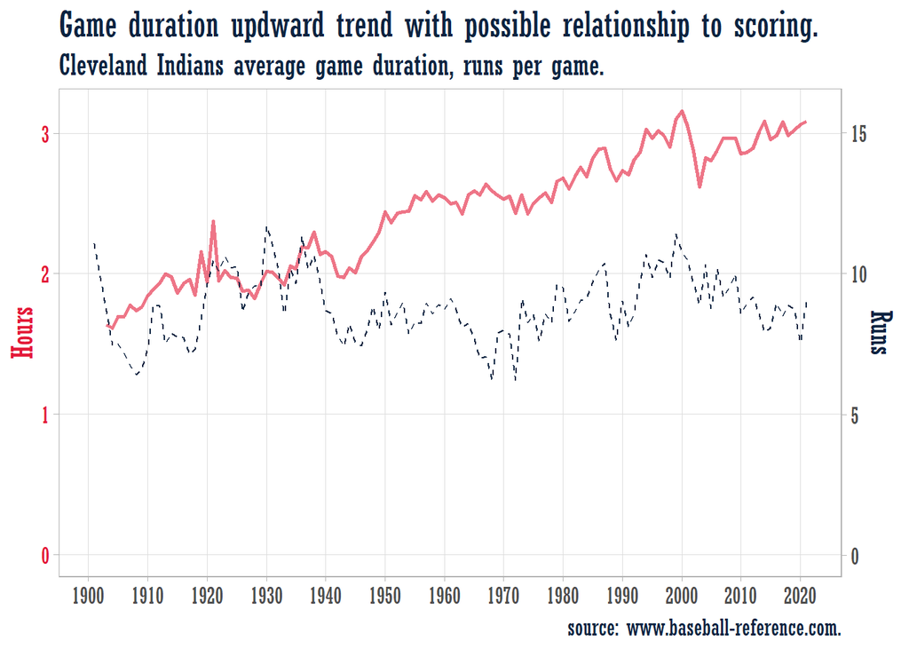

The correlation matrix shows `game_hrs9` is positively correlated with `yr`, but only mildly correlated with `runs9`.

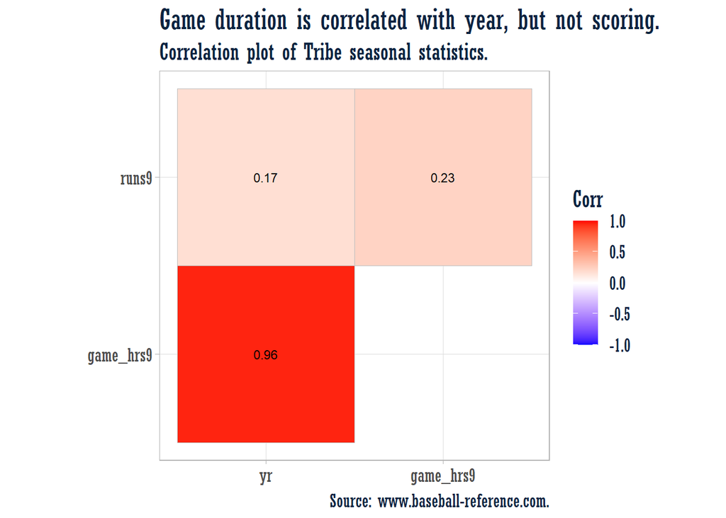

## Fit Model

A good first start is a simple regression on `yr` (or just the trend).

$$\mathrm{DURATION}_t = \beta_0 + \beta_1 \mathrm{YR}_t + \epsilon_t$$

```
## Series: game_hrs9
## Model: TSLM
##
## Residuals:
##      Min       1Q   Median       3Q      Max
## -0.30471 -0.08248 -0.01092  0.07739  0.41993
##
## Coefficients:
##               Estimate Std. Error t value Pr(>|t|)
## (Intercept) -2.066e+01  6.214e-01  -33.25   <2e-16 ***
## yr           1.177e-02  3.167e-04   37.17   <2e-16 ***
## ---
## Signif. codes:  0 '***' 0.001 '**' 0.01 '*' 0.05 '.' 0.1 ' ' 1
##
## Residual standard error: 0.1202 on 118 degrees of freedom
## Multiple R-squared: 0.9213,  Adjusted R-squared: 0.9207
## F-statistic:  1382 on 1 and 118 DF, p-value: < 2.22e-16
```

The modeled $R^2$ is 0.921, the adjusted $R^2$ is 0.921, and the standard error of the regression, $\hat{\sigma}_\epsilon,$ is 0.12 (7 minutes). The fitted to actuals plot has a good linear relationship.

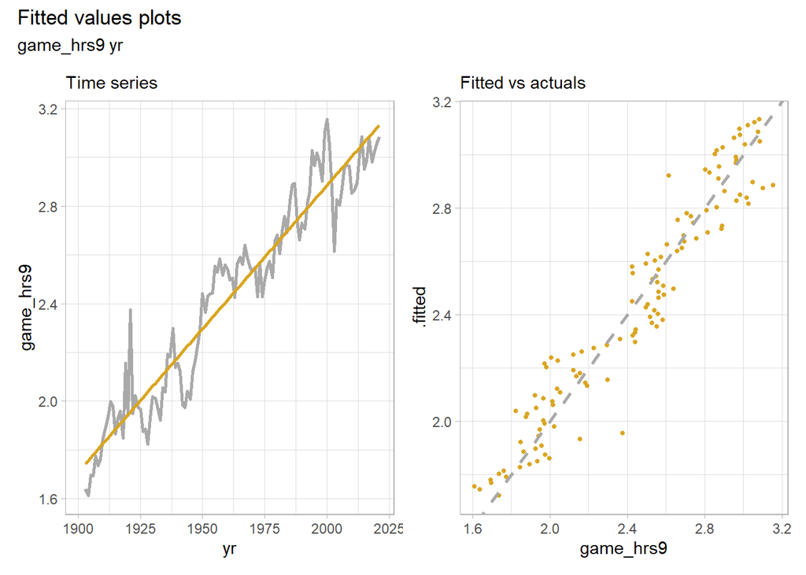

## Model Evaluation

Evaluate the regression model with diagnostic plots. Use `feasts::gg_tsresiduals()` from the tidyverts.

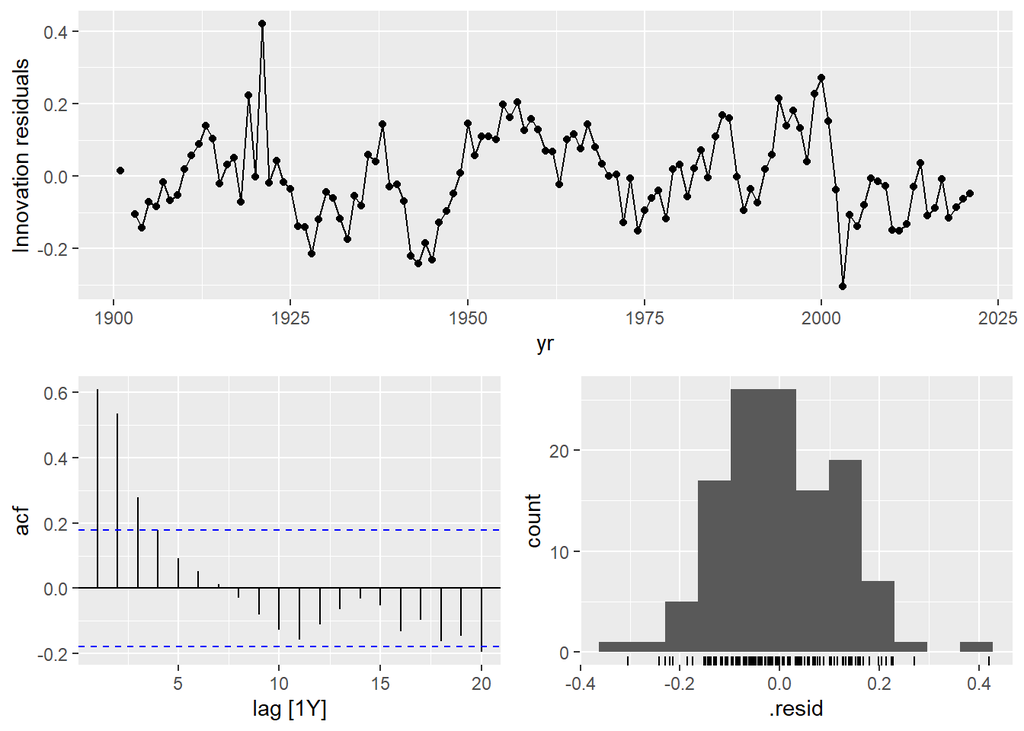

Time series observations are usually related to prior observations. That shows up in diagnostic plots as autocorrelation in the residuals. Autocorrelation in the residuals increases the prediction intervals, making forecasts less efficient (although still unbiased). The autocorrelation function plot (ACF) finds a significant positive spike at lags 1-3 and a negative spike at lag 20.

The residuals vs time diagnostic plot revealed no heteroscedasticity. Heteroscedasticity can make prediction intervals inaccurate.

The histogram shows that the residuals are slightly right-skewed. Non-normality of the residuals can also make the prediction intervals inaccurate.

The residuals should be independent of each of the explanatory variables *and* independent of candidate variables not used in the model. In this case, the residuals have a random pattern in each of the plots.

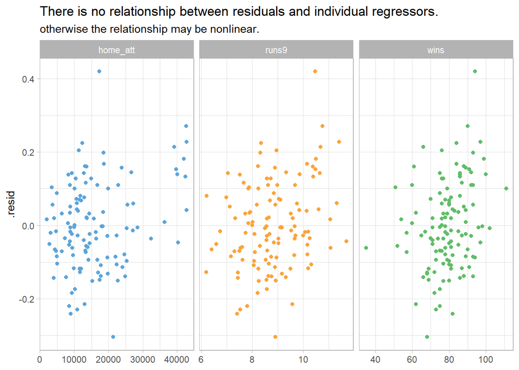

A second check on the homoscedastity assumption is a plot of the residuals against the fitted values. Again, there should be no pattern. This one shows a cyclic pattern.

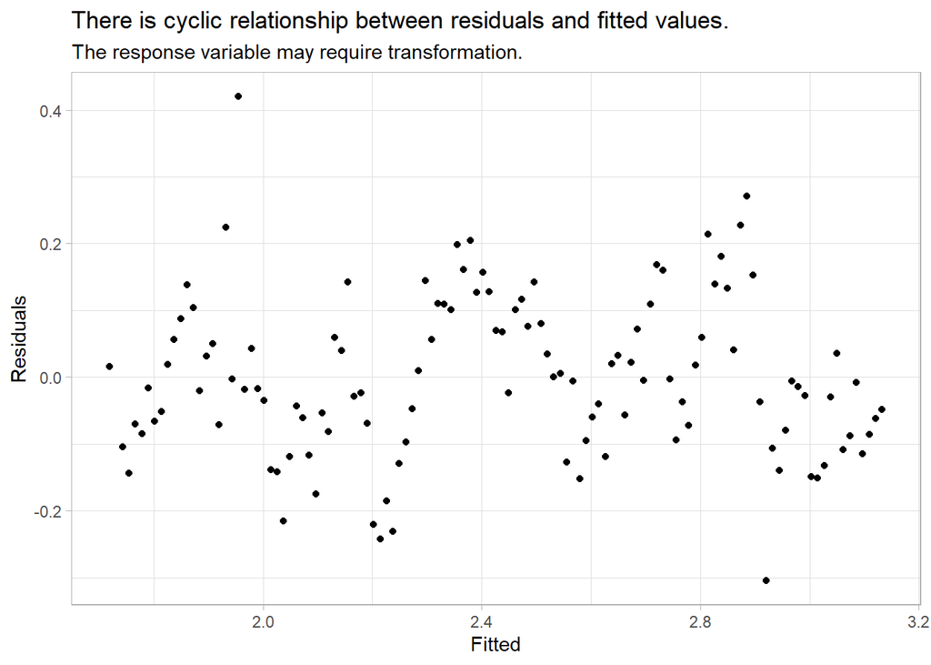

Let’s try a non-linear option. If there are kinks in the response variable trend, you can use piecewise linear regression by defining the knots in the series. In the exploration phase, I identified knots at 1920, 1945, 1955, 1975, 2000, and 2003.

```
## Series: game_hrs9
## Model: TSLM
##
## Residuals:
##       Min        1Q    Median        3Q       Max
## -0.205705 -0.048685 -0.003999  0.053366  0.368289
##
## Coefficients:
##                                                                Estimate
## (Intercept)                                                    1.631315
## trend(knots = c(1920, 1945, 1955, 1975, 2000, 2003))trend      0.018616
## trend(knots = c(1920, 1945, 1955, 1975, 2000, 2003))trend_20  -0.015539
## trend(knots = c(1920, 1945, 1955, 1975, 2000, 2003))trend_45   0.044200
## trend(knots = c(1920, 1945, 1955, 1975, 2000, 2003))trend_55  -0.049069
## trend(knots = c(1920, 1945, 1955, 1975, 2000, 2003))trend_75   0.023535
## trend(knots = c(1920, 1945, 1955, 1975, 2000, 2003))trend_100 -0.110337
## trend(knots = c(1920, 1945, 1955, 1975, 2000, 2003))trend_103  0.104937
##                                                               Std. Error
## (Intercept)                                                     0.040599
## trend(knots = c(1920, 1945, 1955, 1975, 2000, 2003))trend       0.002782
## trend(knots = c(1920, 1945, 1955, 1975, 2000, 2003))trend_20    0.004061
## trend(knots = c(1920, 1945, 1955, 1975, 2000, 2003))trend_45    0.005573
## trend(knots = c(1920, 1945, 1955, 1975, 2000, 2003))trend_55    0.005980
## trend(knots = c(1920, 1945, 1955, 1975, 2000, 2003))trend_75    0.003608
## trend(knots = c(1920, 1945, 1955, 1975, 2000, 2003))trend_100   0.017501
## trend(knots = c(1920, 1945, 1955, 1975, 2000, 2003))trend_103   0.018882
##                                                               t value Pr(>|t|)
## (Intercept)                                                    40.181  < 2e-16
## trend(knots = c(1920, 1945, 1955, 1975, 2000, 2003))trend       6.693 9.06e-10
## trend(knots = c(1920, 1945, 1955, 1975, 2000, 2003))trend_20   -3.826 0.000215
## trend(knots = c(1920, 1945, 1955, 1975, 2000, 2003))trend_45    7.931 1.78e-12
## trend(knots = c(1920, 1945, 1955, 1975, 2000, 2003))trend_55   -8.206 4.31e-13
## trend(knots = c(1920, 1945, 1955, 1975, 2000, 2003))trend_75    6.522 2.07e-09
## trend(knots = c(1920, 1945, 1955, 1975, 2000, 2003))trend_100  -6.305 5.90e-09
## trend(knots = c(1920, 1945, 1955, 1975, 2000, 2003))trend_103   5.558 1.87e-07
##
## (Intercept)                                                   ***
## trend(knots = c(1920, 1945, 1955, 1975, 2000, 2003))trend     ***
## trend(knots = c(1920, 1945, 1955, 1975, 2000, 2003))trend_20  ***
## trend(knots = c(1920, 1945, 1955, 1975, 2000, 2003))trend_45  ***
## trend(knots = c(1920, 1945, 1955, 1975, 2000, 2003))trend_55  ***
## trend(knots = c(1920, 1945, 1955, 1975, 2000, 2003))trend_75  ***
## trend(knots = c(1920, 1945, 1955, 1975, 2000, 2003))trend_100 ***
## trend(knots = c(1920, 1945, 1955, 1975, 2000, 2003))trend_103 ***
## ---
## Signif. codes:  0 '***' 0.001 '**' 0.01 '*' 0.05 '.' 0.1 ' ' 1
##
## Residual standard error: 0.08697 on 112 degrees of freedom
## Multiple R-squared: 0.9609,  Adjusted R-squared: 0.9585
## F-statistic: 393.5 on 7 and 112 DF, p-value: < 2.22e-16
```

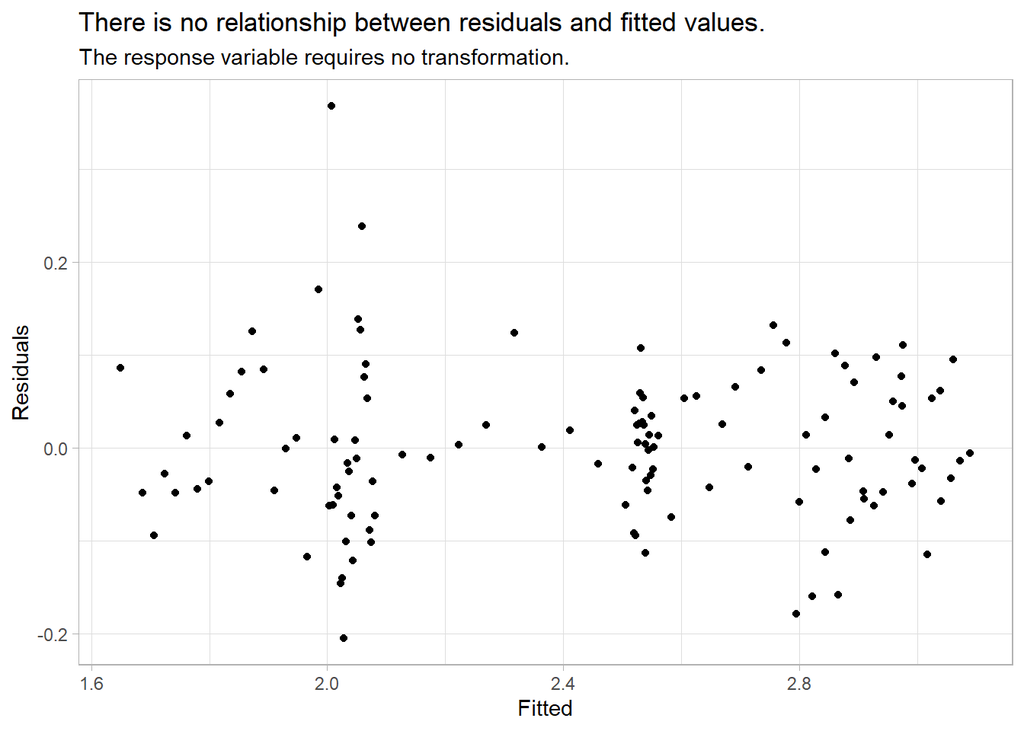

## Predicting Values

Use the model to forecast game durations over the next decade.

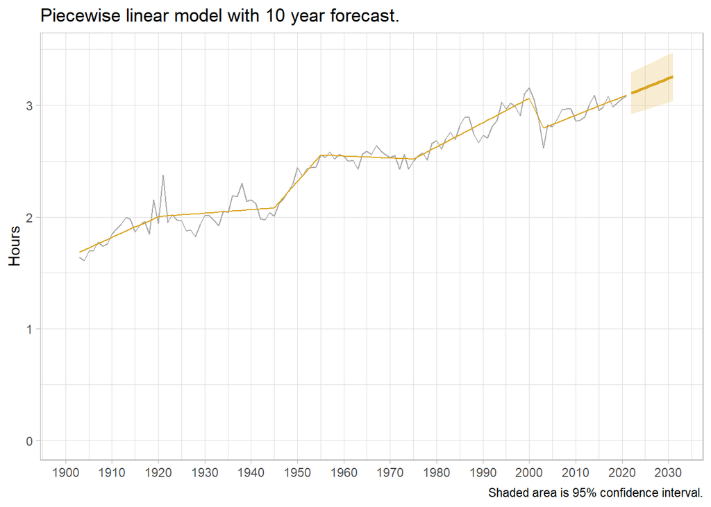

The model predicts game durations to increase to 3:15 by 2031.